# A Day in Digital Life: Understanding Phone Usage Habits

## Introduction

Phones are used in many different ways throughout the day. This visual data story explores phone usage habits using observational logging data collected through a Google Form.

Each observation recorded details such as the time of phone use, the purpose of phone use, phone usage duration, battery level, location, and whether another activity was happening at the same time. The aim of this visual story is to understand when, where, and why phones are being used.

## What are the main phone-use purposes?

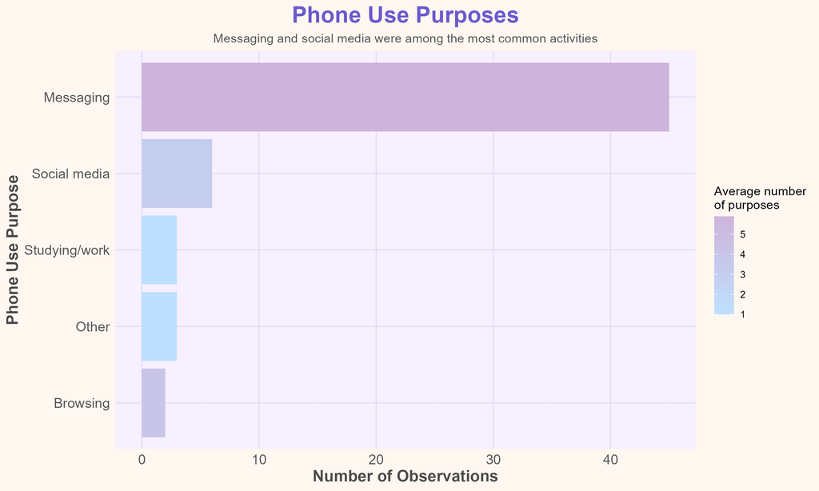

Bar chart showing the main phone-use purposes, with messaging recorded most often.

This visualization shows the main phone-use purposes recorded in the data. Messaging was the most common purpose by far, suggesting that phones were mainly used for communication. Social media, studying/work, browsing, and other activities were also recorded, but less frequently.

The color gradient represents the average number of purposes selected for each observation. This shows that phone use is not always for one single reason. In some observations, phones were used for multiple activities at the same time, such as messaging while browsing, studying, or using social media.

## When is phone use recorded most often?

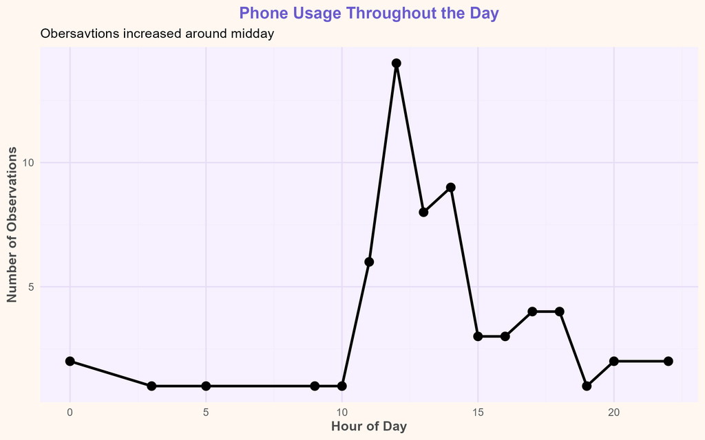

Line chart showing the number of phone-use observations throughout the day by hour.

This visualization uses the timestamp data to show when phone-use observations were recorded. The number of observations increases around the middle of the day, suggesting that phone use was more commonly recorded during daytime hours.

This may reflect respondents routine, where people check their phone between university/work, during breaks, or while completing daily tasks. The plot helps turn the timestamp data into a clearer pattern across the day.

## How does battery level relate to phone usage duration?

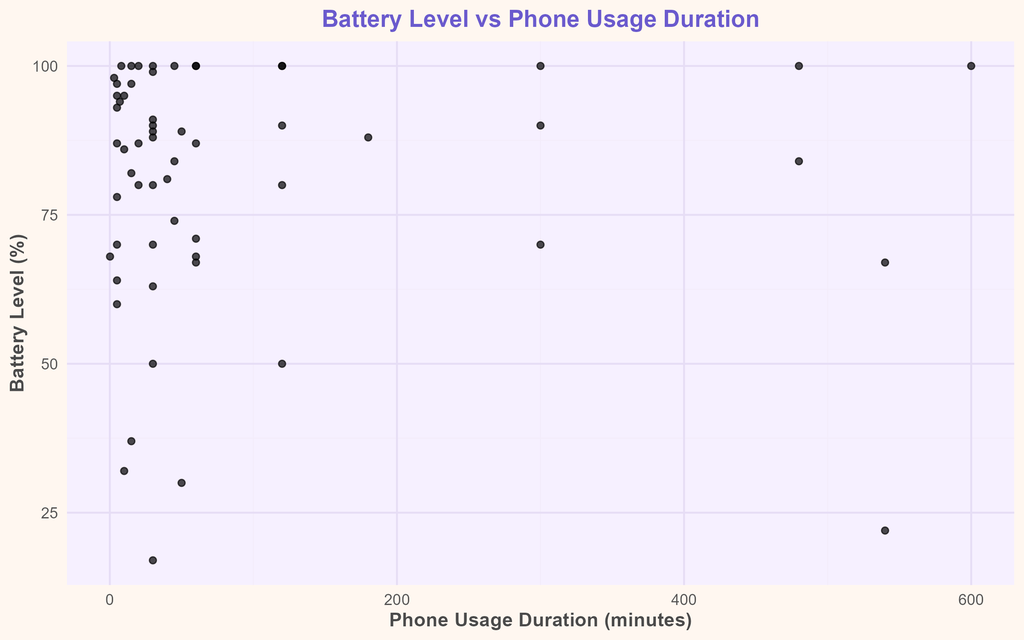

Scatterplot comparing phone usage duration in minutes with battery level at the start of usage.

This scatterplot compares phone usage duration in minutes with battery level at the start of phone use. Most observations are clustered around shorter usage duration, which suggests that many phone-use sessions were brief.

The plot also shows that phone use happened across a wide range of battery levels. Some longer usage sessions started with high battery levels, while shorter sessions occurred at both high and low battery levels. This suggests that battery level alone may not strongly explain how long someone uses their phone.

## What does this reveal?

This visual story shows that phone use is not just one simple behavior. It changes depending on time, purpose, and situation. By using visualizations, the patterns in the data become easier to understand and more interesting to explore.

**POV: Trying to do assignment but my phone said pspspsps**

[figure not shown]